# Results - Prelim. Spa-Temp Experiment

In this notebook, I will be walking through how we can estimate different methods based on the density cubes that we derive.

```
import sys, os
from pyprojroot import here
root = here(project_files=[".here"])
sys.path.append(str(here()))

import pathlib
FIG_PATH = pathlib.Path(str(here())).joinpath('reports/figures/spa_temp/demos')

# standard python packages
import xarray as xr
import pandas as pd
import numpy as np

#
# Experiment Functions
from src.data.esdc import get_dataset
from src.features import Metrics
from src.features.temporal import select_period, get_smoke_test_time
from src.features.spatial import select_region, get_europe
from src.models.train_models import get_similarity_scores
from src.experiments.utils import dict_product, run_parallel_step

from src.features import Metrics
from src.features.density import get_density_cubes
from src.features.preprocessing import standardizer_data, get_reference_cube, get_common_indices
from src.models.similarity import cka_coefficient, rv_coefficient, rbig_it_measures

# # esdc tools
# from src.esdc.subset import select_pixel
# from src.esdc.shape import ShapeFileExtract, rasterize
# from esdc.transform import DensityCubes

from typing import List, Dict
import xarray as xr

from tqdm import tqdm

import cartopy
import cartopy.crs as ccrs

# NUMPY SETTINGS
import numpy as onp
onp.set_printoptions(precision=3, suppress=True)

# MATPLOTLIB Settings
import matplotlib as mpl
import matplotlib.pyplot as plt
%matplotlib inline
%config InlineBackend.figure_format = 'retina'

# SEABORN SETTINGS
import seaborn as sns
sns.set_context(context='talk',font_scale=0.7)
# sns.set(rc={'figure.figsize': (12, 9.)})
# sns.set_style("whitegrid")

# PANDAS SETTINGS
import pandas as pd
pd.set_option("display.max_rows", 120)
pd.set_option("display.max_columns", 120)

# LOGGING SETTINGS
import sys
import logging
logging.basicConfig(
    level=logging.INFO,
    stream=sys.stdout,
    format='%(asctime)s:%(levelname)s:%(message)s'
)
logger = logging.getLogger()
#logger.setLevel(logging.INFO)

%load_ext autoreload
%autoreload 2
```

## Results Plot

For this first set of results, I'm looking at the following:

- Entropy of the different spatial-temporal density cube compositions.
- MI between just the sames with not spatial-temporal features and the density cubes with different spatiel-temporal compositions.

**Hypothesis**

- Less mutual information with more features
- I'm not sure about entropy.

```
!ls /home/emmanuel/projects/2020_rbig_rs/data/spa_temp/trial_experiment/
```

```
v1_gpp_europe.csv     v1_reg_lst_spain.csv  v2_gpp_europe.csv  v5_gpp_spain.csv
v1_gpp_spain.csv      v1_reg_rm_spain.csv   v3_gpp_europe.csv  v5_lst_spain.csv
v1_lst_europe.csv     v1_reg_sm_spain.csv   v3_lst_spain.csv   v5_rm_spain.csv
v1_lst_spain.csv      v1_rm_europe.csv      v4_gpp_spain.csv
v1_precip_europe.csv  v1_rm_spain.csv       v4_lst_spain.csv
v1_reg_gpp_spain.csv  v1_sm_spain.csv       v4_rm_spain.csv
```

```
RES_PATH = pathlib.Path(str(root)).joinpath(
    "data/spa_temp/trial_experiment/v1_gpp_spain.csv"
)
results = pd.read_csv(str(RES_PATH))
# results['ratio'] = results['spatial'] / results['temporal']
variable = 'gpp'
results.tail()
```

|  | Unnamed: 0 | region | period | variable | spatial | temporal | n_dimensions | rv_coef | x_norm | y_norm | xy_norm | cka_coeff | cka_y_norm | cka_x_norm | cka_xy_norm | rbig_H_x | rbig_H_y | rbig_H_time | rbig_I_xy | rbig_I_time | rbig_I_xx | rbig_Ixx_time |
| --- | --- | --- | --- | --- | --- | --- | --- | --- | --- | --- | --- | --- | --- | --- | --- | --- | --- | --- | --- | --- | --- | --- |
| 19 | 0 | spain | 201001_201012 | gross_primary_productivity | 5 | 2 | 49 | 0.701670 | 9822.754 | 356234.380 | 2.455285e+09 | 0.390665 | 244.634810 | 3164.364637 | 302418.856996 | 1.618394 | -31.628943 | 5.964067 | 2.726618 | 72.548164 | 24.870119 | 2.706781 |
| 20 | 0 | spain | 201001_201012 | gross_primary_productivity | 4 | 3 | 49 | 0.724556 | 10016.861 | 359273.030 | 2.607524e+09 | 0.405141 | 298.083405 | 3152.776822 | 380747.174065 | 1.628707 | -41.801587 | 6.212985 | 2.638460 | 71.020401 | 26.165167 | 3.776454 |
| 21 | 0 | spain | 201001_201012 | gross_primary_productivity | 3 | 5 | 49 | 0.727479 | 10138.089 | 349347.620 | 2.576526e+09 | 0.406521 | 323.738611 | 3151.328151 | 414734.978387 | 1.647154 | -44.876359 | 6.179050 | 2.579538 | 69.986285 | 25.551909 | 3.070246 |
| 22 | 0 | spain | 201001_201012 | gross_primary_productivity | 2 | 12 | 49 | 0.531356 | 9925.461 | 334340.160 | 1.763295e+09 | 0.307230 | 160.604180 | 3181.042013 | 156960.325847 | 1.717331 | -45.166306 | 6.167195 | 2.628749 | 76.820187 | 25.614716 | 2.861449 |
| 23 | 0 | spain | 201001_201012 | gross_primary_productivity | 1 | 46 | 46 | 0.620548 | 899.000 | 27489.203 | 1.533548e+07 | 0.431151 | 8.754000 | 288.901196 | 1090.399509 | 1.834853 | -36.622683 | 2.057764 | 1.433021 | 41.538069 | 25.383197 | 0.593684 |

## Entropy

```
sub_df = results.copy()

sub_df['ratio'] = sub_df['spatial'] / sub_df['temporal']
# sub_df['dimensions'] = sub_df['spatial'] ** 2 + sub_df['temporal']

# sub_df['nH'] = (sub_df['rbig_H_y'] /  sub_df['dimensions']) #* np.log(2)
sub_df["spatial"] = sub_df["spatial"].astype('category')
sub_df["temporal"] = sub_df["temporal"].astype('category')
sub_df["n_dimensions"] = sub_df["n_dimensions"].astype('category')

fig, ax = plt.subplots(ncols=1, figsize=(7, 5))

sns.scatterplot(x='ratio', y='rbig_H_y', hue='n_dimensions', data=sub_df, ax=ax, label='Entropy',)
# sns.scatterplot(x='ratio', y='rv_coeff', data=sub_df, ax=ax, label='RV')
ax.set(xscale='log',
       xlabel='Spatial / Temporal Ratio',
       ylabel='Entropy'
      )

plt.show()

fig, ax = plt.subplots(ncols=1, figsize=(7, 5))

sns.lineplot(x='ratio', y='rbig_H_y', hue='n_dimensions', data=sub_df, ax=ax,)
# sns.scatterplot(x='ratio', y='rv_coeff', data=sub_df, ax=ax, label='RV')
ax.set(
    xscale='log',
       xlabel='Spatial / Temporal Ratio',
       ylabel='Entropy'
      )
plt.tight_layout()
fig.savefig(FIG_PATH.joinpath(f'{variable}_entropy.png'))
plt.show()
```

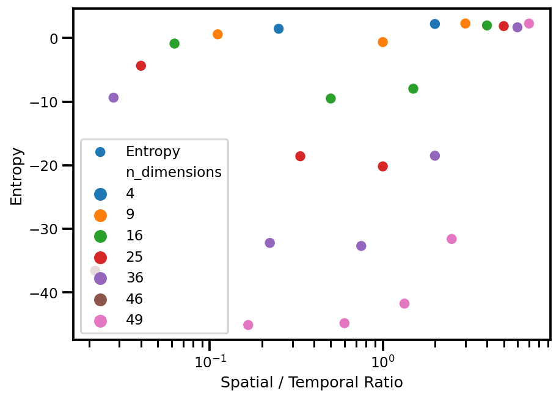

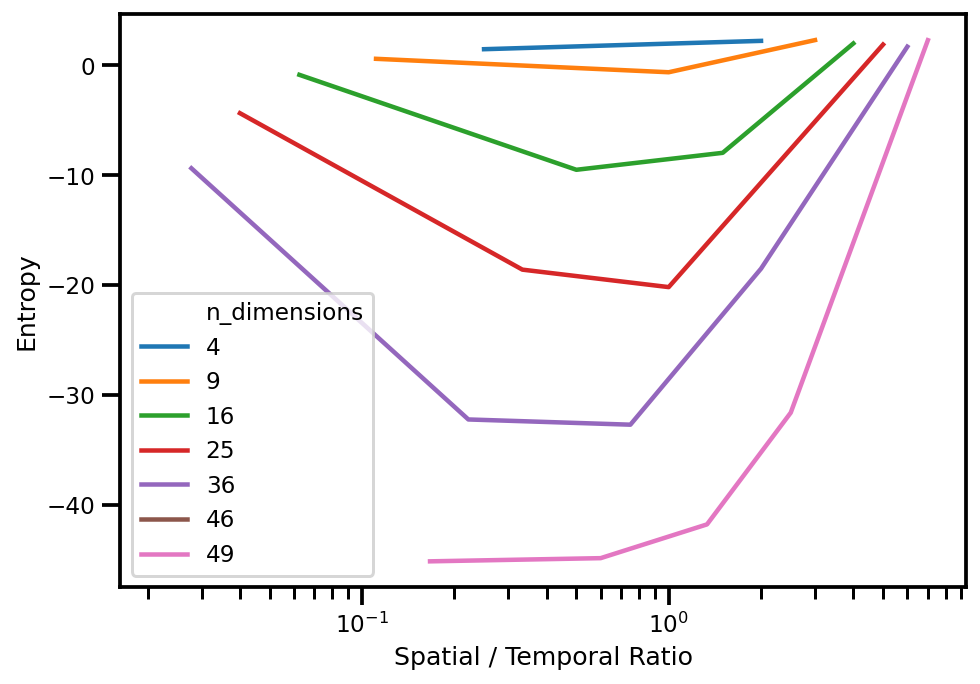

### Normalized

We can normalize the entropy using a bias term:

```
sub_df = results.copy()

# find the min,max values
min_H = sub_df[['rbig_H_y', 'rbig_H_x']].min().min()
max_H = sub_df[['rbig_H_y', 'rbig_H_x']].max().max()

# Rescale via min/max values

def logbias(x):
    return x + np.abs(min_H)

print(min_H, max_H)
print(sub_df['rbig_H_y'].min(), sub_df['rbig_H_y'].max())
sub_df['H_y_bias'] = sub_df['rbig_H_y'].apply(logbias) # /sub_df["n_dimensions"]
sub_df['H_x_bias'] = sub_df['rbig_H_x'].apply(logbias)
print(sub_df['H_y_bias'].min(), sub_df['H_y_bias'].max())
# Plot stuff
sub_df['ratio'] = sub_df['spatial'] / sub_df['temporal']
sub_df["spatial"] = sub_df["spatial"].astype('category')
sub_df["temporal"] = sub_df["temporal"].astype('category')
sub_df["n_dimensions"] = sub_df["n_dimensions"].astype('category')
```

```
-45.16630554701285 2.2991785054047473
-45.16630554701285 2.2991785054047473
0.0 47.465484052417594
```

```
fig, ax = plt.subplots(ncols=1, figsize=(7, 5))

sns.lineplot(x='ratio', y='H_y_bias', hue='n_dimensions', data=sub_df, ax=ax,)
# sns.scatterplot(x='ratio', y='rv_coeff', data=sub_df, ax=ax, label='RV')
ax.set(
    xscale='log',
#     yscale='symlog',
    xlabel='Spatial / Temporal Ratio',
    ylabel='Entropy'
      )
plt.tight_layout()
fig.savefig(FIG_PATH.joinpath(f'{variable}_n_entropy.png'))
plt.show()
```

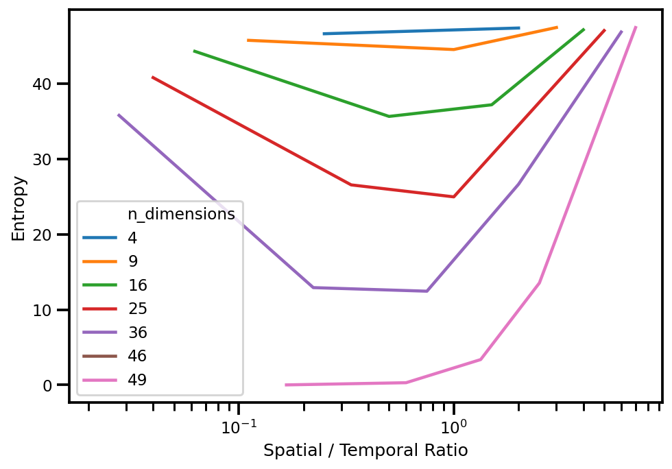

## Mutual Information

```
sub_df = results.copy()

# Plot stuff
sub_df['ratio'] = sub_df['spatial'] / sub_df['temporal']
sub_df["spatial"] = sub_df["spatial"].astype('category')
sub_df["temporal"] = sub_df["temporal"].astype('category')
sub_df["n_dimensions"] = sub_df["n_dimensions"].astype('category')

# sub_df['rbig_I_xy'] = sub_df['rbig_I_xy']# * np.log(2)

# # Figure
# fig, ax = plt.subplots(ncols=1, figsize=(7, 5))

# sns.scatterplot(x='ratio', y='rbig_I_xy', hue='n_dimensions', data=sub_df, ax=ax, label='Entropy',)
# # sns.scatterplot(x='ratio', y='rv_coeff', data=sub_df, ax=ax, label='RV')
# ax.set(xscale='log',
#        xlabel='Spatial / Temporal Ratio',
#        ylabel='Mutual Information'
#       )

# plt.show()
fig, ax = plt.subplots(ncols=1, figsize=(7, 5))

sns.lineplot(x='ratio', y='rbig_I_xy', hue='n_dimensions', data=sub_df, ax=ax,)
# sns.scatterplot(x='ratio', y='rv_coeff', data=sub_df, ax=ax, label='RV')
ax.set(
    xscale='log',
#     yscale='symlog',
    xlabel='Spatial / Temporal Ratio',
    ylabel='Mutual Information',
#     ylim=[-0.05, 0.6]
      )
plt.tight_layout()
fig.savefig(FIG_PATH.joinpath(f'{variable}_mi.png'))
plt.show()
```

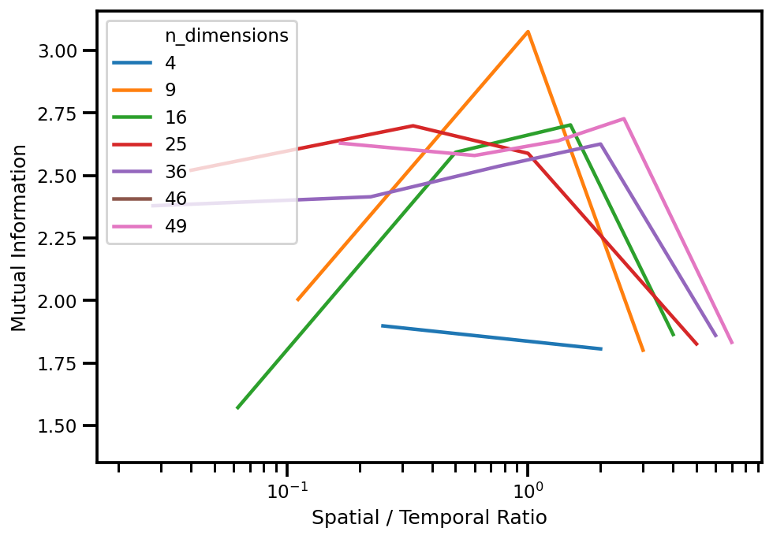

### Normalized Mutual Information

$$ \text{nI}(\mathbf{X,Y}) = \frac{I(\mathbf{X,Y})}{\sqrt{H(\mathbf{X})H(\mathbf{Y})}} $$

```
# ==============
# Entropy Bias
# ==============

sub_df = results.copy()

# find the min,max values
min_H = sub_df[['rbig_H_y', 'rbig_H_x']].min().min()
max_H = sub_df[['rbig_H_y', 'rbig_H_x']].max().max()

# Rescale via min/max values

def logbias(x):
    return x + np.abs(min_H)

sub_df['H_y_bias'] = sub_df['rbig_H_y'].apply(logbias) # /sub_df["n_dimensions"]
sub_df['H_x_bias'] = sub_df['rbig_H_x'].apply(logbias)


# ==============
# Normalized MI
# ==============
sub_df['I_norm'] = sub_df['rbig_I_xy'] / np.sqrt(sub_df['H_x_bias']) / np.sqrt(sub_df['H_y_bias'])

# Plot stuff
sub_df['ratio'] = sub_df['spatial'] / sub_df['temporal']
sub_df["spatial"] = sub_df["spatial"].astype('category')
sub_df["temporal"] = sub_df["temporal"].astype('category')
sub_df["n_dimensions"] = sub_df["n_dimensions"].astype('category')
```

```
# plt.show()
fig, ax = plt.subplots(ncols=1, figsize=(7, 5))

sns.lineplot(x='ratio', y='I_norm', hue='n_dimensions', data=sub_df, ax=ax,)
# sns.scatterplot(x='ratio', y='rv_coeff', data=sub_df, ax=ax, label='RV')
ax.set(
    xscale='log',
#     yscale='log',
    xlabel='Spatial / Temporal Ratio',
    ylabel='Mutual Information'
      )
plt.tight_layout()
fig.savefig(FIG_PATH.joinpath(f'{variable}_nmi.png'))
plt.show()
```

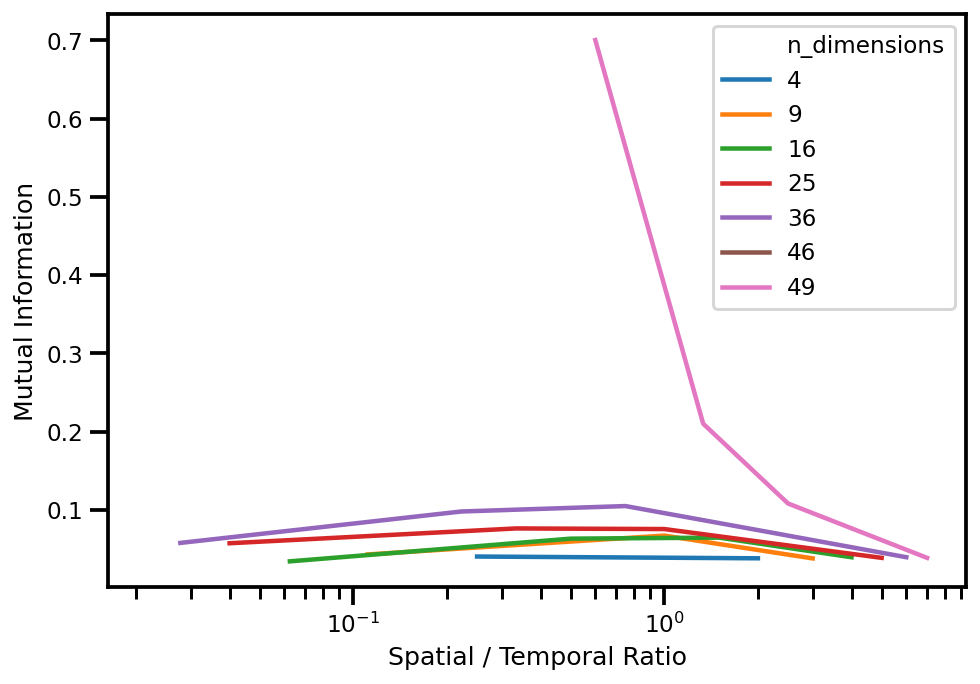

## RV Coefficient

```
# plt.show()
fig, ax = plt.subplots(ncols=1, figsize=(7, 5))

sns.lineplot(x='ratio', y='rv_coef', hue='n_dimensions', data=sub_df, ax=ax,)
# sns.scatterplot(x='ratio', y='rv_coeff', data=sub_df, ax=ax, label='RV')
ax.set(
    xscale='log',
#     yscale='log',
    xlabel='Spatial / Temporal Ratio',
    ylabel='RV Coefficient',
      )
plt.tight_layout()
fig.savefig(FIG_PATH.joinpath(f'{variable}_rv.png'))
plt.show()
```

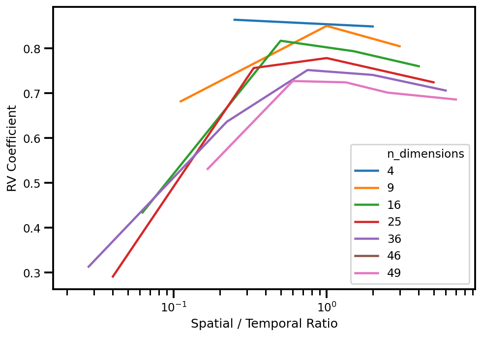

## CKA

```
# Plot stuff
sub_df = results.copy()
sub_df['ratio'] = sub_df['spatial'] / sub_df['temporal']
sub_df["spatial"] = sub_df["spatial"].astype('category')
sub_df["temporal"] = sub_df["temporal"].astype('category')
sub_df["n_dimensions"] = sub_df["n_dimensions"].astype('category')
sub_df["cka_xy_norm"] *= (1 / (10_000**2))

# plt.show()
fig, ax = plt.subplots(ncols=1, figsize=(7, 5))

sns.lineplot(x='ratio', y='cka_coeff', hue='n_dimensions', data=sub_df, ax=ax,)
# sns.scatterplot(x='ratio', y='rv_coeff', data=sub_df, ax=ax, label='RV')
ax.set(
    xscale='log',
#     yscale='log',
    xlabel='Spatial / Temporal Ratio',
    ylabel='cKernel Alignment',
#     ylim=[0.0, 0.0015]
      )
plt.tight_layout()
fig.savefig(FIG_PATH.joinpath(f'{variable}_cka.png'))
plt.show()
```

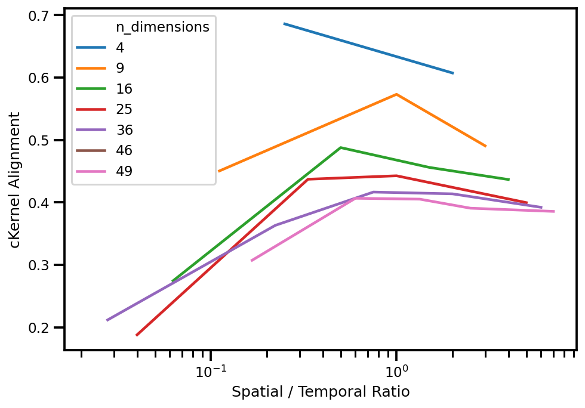

So we see that the configuration with more features has less entropy?

## Variation of Information

There are a few ways to calculate VI and I will outline how we can calculate them and their normalized variants.

#### Method I - Variation of Information

Firstly, the VI measure was developed by [Meila, 2007](https://www.sciencedirect.com/science/article/pii/S0047259X06002016) [pg 879, eq 19] and is written as:

$$\begin{aligned}
\text{VI} &= H(X,Y) - I(X,Y) \\
&= H(X) + H(Y) - 2 I (X,Y)
\end{aligned}$$

To get the normalized variant, we can use the measure was developed by [Meila, 2007](https://www.sciencedirect.com/science/article/pii/S0047259X06002016) [pg 886, sec 5.1] which is called the *Adjusted VI distance*. Knowing that the VI measure is upper bounded by $\log N$ [Meila, 2007](https://www.sciencedirect.com/science/article/pii/S0047259X06002016) [pg 881, eq. 24], they simply divide the VI measure by $\log N$ to get a measure between 0 and 1. So we get

$$d_\text{norm}(X;Y) = \frac{V(X;Y)}{\log N} = \frac{H(X)+H(Y)-2I(X;Y)}{\log N}$$

**Note**: In theory, this should be bounded between 0 and 1 but I'm not sure what happens with nevative values...

```
# get number of samples
n_samples = sub_df['rbig_H_x'].shape[0]

# calculate variation of information
sub_df['vi_joint'] = sub_df['rbig_H_x'] + sub_df['rbig_H_y'] - 2 * sub_df['rbig_I_xy']
sub_df['vi_joint_norm'] = (sub_df['vi_joint']) / np.log(n_samples)


# Plot Unnormalized
fig, ax = plt.subplots(ncols=2, figsize=(10, 5))

sns.scatterplot(x='ratio', y='vi_joint', data=sub_df, hue='n_dimensions', ax=ax[0], label='nMI')
sns.scatterplot(x='ratio', y='vi_joint', data=sub_df, hue='n_dimensions', ax=ax[1], label='nMI')

# sns.scatterplot(x='ratio', y='rv_coeff', data=sub_df, ax=ax[1], label='RV')
ax[0].set_yscale('symlog')
ax[0].set_xscale('log')
ax[0].set_ylabel('VI (Meila 2005)')
ax[0].set_xlabel('Spatial / Temporal Ratio')

ax[1].set_yscale('symlog')
ax[1].set_xscale('log')
ax[1].set_ylabel('')
ax[1].set_xlabel('Spatial / Temporal Ratio')


# Plot Normalized
fig, ax = plt.subplots(ncols=2, figsize=(10, 5))

sns.scatterplot(x='ratio', y='vi_joint_norm', data=sub_df, hue='n_dimensions', ax=ax[0], label='nMI')
sns.scatterplot(x='ratio', y='vi_joint_norm', data=sub_df, hue='n_dimensions', ax=ax[1], label='nMI')

# sns.scatterplot(x='ratio', y='rv_coeff', data=sub_df, ax=ax[1], label='RV')
ax[0].set_yscale('symlog')
ax[0].set_xscale('log')
ax[0].set_ylabel('Normalized VI (Meila 2007)')
ax[0].set_xlabel('Spatial / Temporal Ratio')

ax[1].set_yscale('symlog')
ax[1].set_xscale('log')
ax[1].set_ylabel('')
ax[1].set_xlabel('Spatial / Temporal Ratio')
```

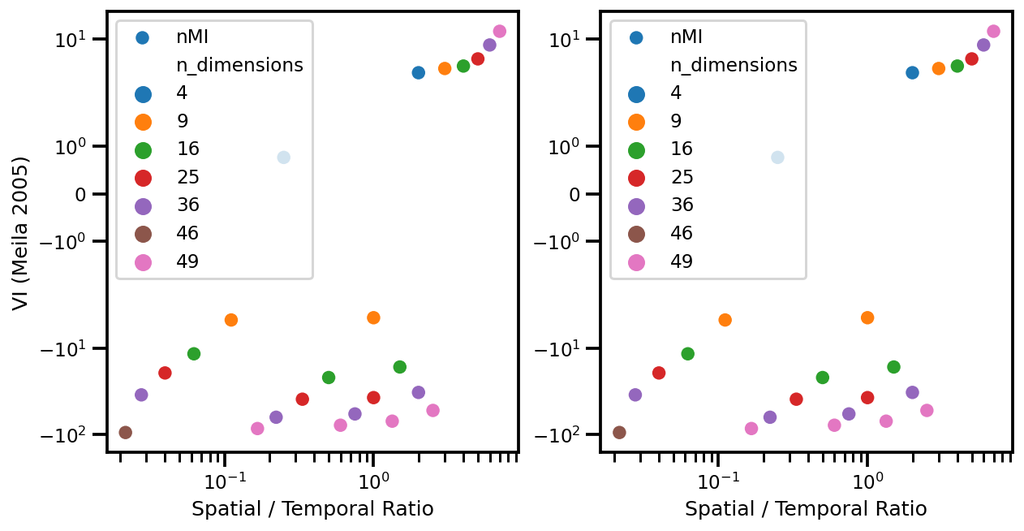

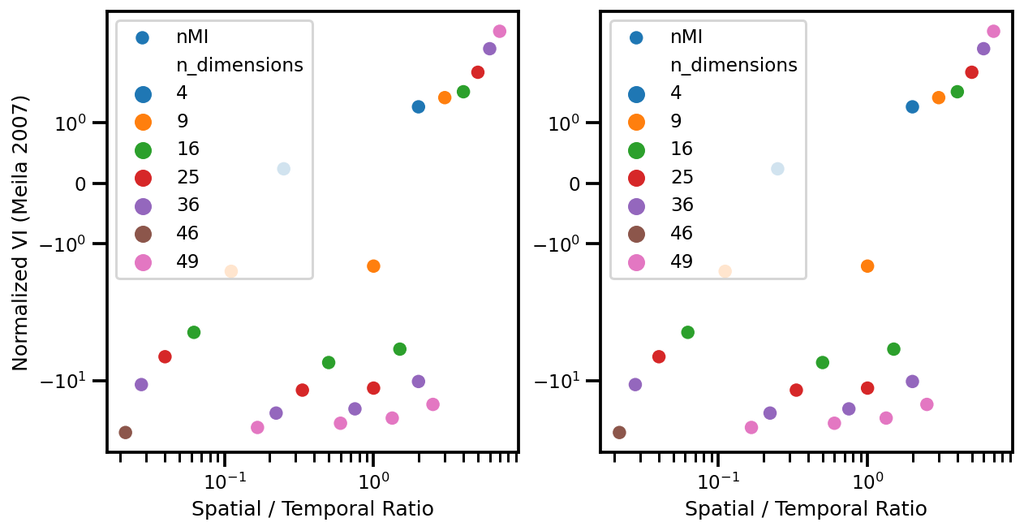

So this is a bit difficult to interpret because of the negative values. But what they **should** mean is that there is very, very little mutual information. Which is technically true from the results. However, the scale is a bit ridiculous.

#### Method III - Variation of Information (Joint)

This is analogous to the measure above but the way they do the normalization is different. This one I found in [this paper](http://jmlr.csail.mit.edu/papers/volume11/vinh10a/vinh10a.pdf) [pg. 2842, table 3].

$$d_\text{joint}(I;Y) = \frac{VI(X;Y)}{H(X;Y)} = 1 - \frac{I(X;Y)}{H(X,Y)}$$

**Note**: Below I show how the quantity on the right is equivalent to the middle term:

$$ \begin{aligned} 1 - \frac{I(X;Y)}{H(X,Y)} &= 1 - \frac{I(X;Y)}{H(X) + H(Y) - I(X;Y)} \ &= \frac{H(X) + H(Y) - I(X;Y)}{H(X) + H(Y) - I(X;Y)} - \frac{I(X;Y)}{H(X) + H(Y) - I(X;Y)} \ &= \frac{H(X) + H(Y) - 2I(X;Y)}{H(X) + H(Y) - I(X;Y)} \ &= \frac{VI(X;Y)}{H(X,Y)} \end{aligned} $$

```
# get number of samples
n_samples = sub_df['rbig_H_x'].shape[0]

# calculate variation of information
sub_df['vi'] = sub_df['rbig_H_x'] + sub_df['rbig_H_y'] - 2 * sub_df['rbig_I_xy']
sub_df['H_xy'] =  sub_df['rbig_H_x'] + sub_df['rbig_H_y'] - sub_df['rbig_I_xy']
sub_df['nVI_joint'] = sub_df['vi'] / sub_df['H_xy']

# sub_df['d_joint'] = 1 - (sub_df['rbig_I_xy'] / sub_df['H_xy'])

# Plot Unnormalized
fig, ax = plt.subplots(ncols=2, figsize=(10, 5))

sns.scatterplot(x='ratio', y='nVI_joint', data=sub_df, hue='n_dimensions', ax=ax[0], label='nMI')
sns.scatterplot(x='ratio', y='nVI_joint', data=sub_df, hue='n_dimensions', ax=ax[1], label='nMI')

# sns.scatterplot(x='ratio', y='rv_coeff', data=sub_df, ax=ax[1], label='RV')
ax[0].set_yscale('log')
# ax[0].set_ylim([0.9, 1.1])
ax[0].set_xscale('log')
ax[0].set_ylabel('nVI (Joint) (Kaskov 2005)')
ax[0].set_xlabel('Spatial / Temporal Ratio')

ax[1].set_yscale('log')
ax[1].set_xscale('log')
ax[1].set_ylabel('')
ax[1].set_xlabel('Spatial / Temporal Ratio')
```

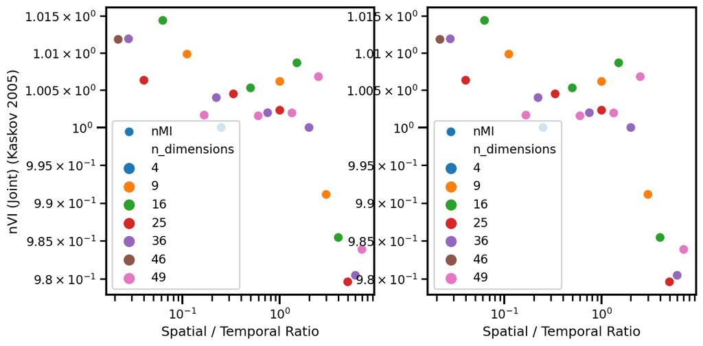

Furthermore, I didn't estimate the joint entropy $H(X,Y)$ directly with RBIG. So we could be introducing a lot of errors by doing all of the manipulations to acquire the joint entropy.

#### Method III - Variation of Information (Max)

This is the last variation of the VI method found in [this paper](http://jmlr.csail.mit.edu/papers/volume11/vinh10a/vinh10a.pdf) [pg. 2842, table 3].

$$d_\text{max}(I;Y) = 1 - \frac{I(X;Y)}{\text{max}\left\{ H(X),H(Y) \right\}}$$

And apparently this is the tightest bound over the VI measure. Another name is called the **Normalized Information Distance**.

```
sub_df['nVI_max'] = 1 - (sub_df['rbig_I_xy'] /  np.maximum(sub_df['rbig_H_x'], sub_df['rbig_H_y']))

fig, ax = plt.subplots(ncols=2, figsize=(10, 5))

sns.scatterplot(x='ratio', y='nVI_max', data=sub_df, hue='n_dimensions', ax=ax[0], label='nMI')
sns.scatterplot(x='ratio', y='nVI_max', data=sub_df, hue='n_dimensions', ax=ax[1], label='nMI')

# sns.scatterplot(x='ratio', y='rv_coeff', data=sub_df, ax=ax[1], label='RV')
# ax[0].set_yscale('log')
# ax[0].set_ylim([0.9, 1.1])
ax[0].set(
    xscale='log',
    ylabel='nVI (Max) (Kaskov 2005)',
    xlabel='Spatial / Temporal Ratio'
)
ax[1].set(
    xscale='log',
    ylabel='',
    xlabel='Spatial / Temporal Ratio'
)


plt.tight_layout()
plt.show()
```

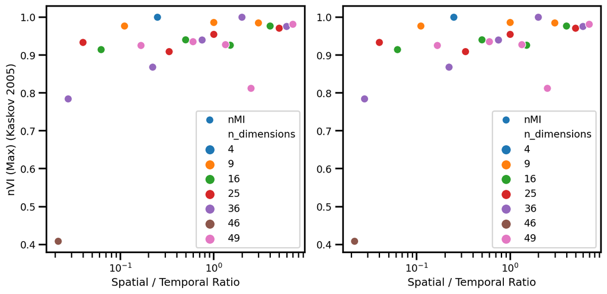

So this one makes a lot more sense to me. I expected that we would get something where we see more MI amongst data already seen and less MI with more features because there are unseen cases. So I quite like this setup. Also, apparently the distance measure is an actual metric that satisfies the key properties. So this is also another plus.

Now, later, I will have to figure out how this ties into the Taylor Diagram. But for now, I'm quite happy.

```
from sklearn.preprocessing import MinMaxScaler

# find the min,max of all entropy values
min_H = sub_df[['rbig_H_x', 'rbig_H_y']].min().min()
max_H = sub_df[['rbig_H_x', 'rbig_H_y']].max().max()

# Scale between 0 and the max value?
sub_df['rbig_H_xs'] = MinMaxScaler((0, max_H)).fit_transform(sub_df['rbig_H_x'].values[:, None])
sub_df['rbig_H_ys'] = MinMaxScaler((0, max_H)).fit_transform(sub_df['rbig_H_y'].values[:, None])

# calculate normalized MI with the scaled versions
sub_df['d_max'] = (sub_df['rbig_I_xy'] /  np.sqrt(sub_df['rbig_H_xs']) / np.sqrt(sub_df['rbig_H_ys'])) #* np.log(2)
```

```
fig, ax = plt.subplots(ncols=2, nrows=2, figsize=(10, 10))



sns.scatterplot(x='ratio', y='d_max', data=sub_df, hue='n_dimensions', ax=ax[0,0], label='nMI')
sns.scatterplot(x='ratio', y='d_max', data=sub_df, hue='n_dimensions', ax=ax[0,1], label='nMI')

# sns.scatterplot(x='ratio', y='rv_coeff', data=sub_df, ax=ax[1], label='RV')
# ax[0,0].set_yscale('log')
ax[0,0].set_xscale('log')
ax[0,0].set_ylabel('Normalized Mutual Information')
ax[0,0].set_xlabel('Spatial / Temporal Ratio')

# ax[0, 1].set_yscale('log')
ax[0, 1].set_xscale('log')
ax[0, 1].set_ylabel('')
ax[0, 1].set_xlabel('Spatial / Temporal Ratio')


sns.scatterplot(x='ratio', y='rv_coeff', data=sub_df, hue='n_dimensions', ax=ax[1,0], label='nMI')
sns.scatterplot(x='ratio', y='rv_coeff', data=sub_df, hue='n_dimensions', ax=ax[1,1], label='nMI')

# sns.scatterplot(x='ratio', y='rv_coeff', data=sub_df, ax=ax[1], label='RV')
ax[1,0].set_yscale('log')
ax[1,0].set_xscale('log')
ax[1,0].set_ylabel('Coefficient')
ax[1,0].set_xlabel('Spatial / Temporal Ratio')

ax[1, 1].set_yscale('log')
ax[1, 1].set_xscale('log')
ax[1, 1].set_ylabel('')
ax[1, 1].set_xlabel('Spatial / Temporal Ratio')
plt.show()
```

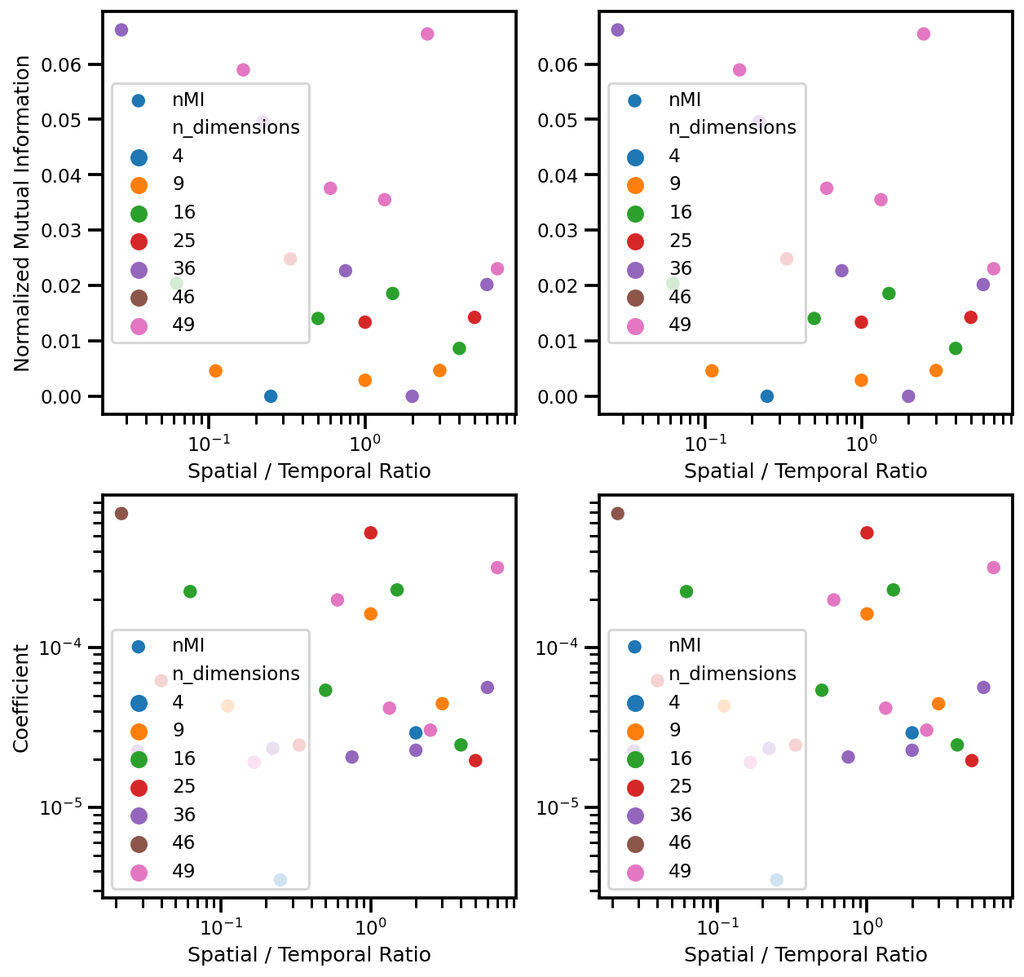

**RV Coefficient**

**Mutual Information**

MI clearly has a pattern. That's good, it's picking up something about the feature representations. The only problem is it's difficult to interpret because it's not really between 0 and 1, so I'm not sure how we're supposed to use this in a Taylor Diagram.